# SHAP-based prioritisation of colorectal cancer DMRs (nsim = 500)

YC

2026-07-22

# Overview

This report prioritises the final 110 DMR candidates for wet-lab validation using the radial SVM model and the TCGA full cohort. -SHAP values are calculated for all 110 DMRs before candidate ranking. -The final priority score combines 60% scaled SHAP importance and 40% scaled discovery-stage regional delta beta.

The discovery delta beta used here is matched from the Step 1 DMRcate `meandiff` column by exact chromosome, start, and end coordinates. The previous value that had been copied from the validation-stage `mean_deltaBeta` is retained only for auditing.

## Analysis workflow

1. Load the trained radial SVM model and TCGA full-cohort feature matrix.
2. Restore the true discovery-stage delta beta for all 110 DMRs.
3. Calculate SHAP values with `nsim = 500`.
4. Calculate TCGA Tumor-minus-Normal delta beta as external supporting evidence.
5. Calculate the combined priority score and select the final top 10 DMRs.
6. Generate summary tables and visualisations.

# TCGA full-cohort SHAP prioritisation

The analysis begins from a clean R environment, sets numerical display options, and fixes the random seed.

```r
rm(list = ls())

options(stringsAsFactors = FALSE)
options(scipen = 20)

set.seed(123)
```

Using the same seed makes the Monte Carlo SHAP calculation reproducible for the specified software environment.

This chunk loads the packages used for data handling, model prediction, SHAP estimation, statistical evaluation, and plotting.

```r
library(data.table)
library(caret)
library(fastshap)
library(ggplot2)
library(ggbeeswarm)
library(pROC)
library(kernlab)
```

All subsequent analysis steps depend on these packages being loaded successfully.

This chunk defines the four required input files and a new output directory so that the corrected results do not overwrite earlier analyses.

```r
## Trained ML models from GSE101764.
## Expected objects:
##   model_svm, model_rf, model_glmnet, ml_df, feature_name_map
training_model_file <- "GSE101764_ML_training_3models_110DMRs.Rdata"

## TCGA full testing results.
## Expected object:
##   test_df_full
tcga_testing_file <- "TCGA_full_testing_results_3models.Rdata"

## Final 110 DMR table after other-normal-tissue and whole-blood filtering.
final_dmr_file <- "final_DMRs_after_GSE196696_whole_blood_filter.csv"

## Step 1 DMRcate discovery result.
## The meandiff column is the true discovery-stage regional delta beta.
discovery_dmr_file <- "dmr_hyper_dmrcate_meta.csv"

## Use a new output directory so the previous nsim500 results are not overwritten.
outdir <- "step5.SHAP_selection_nsim500_corrected_discovery_delta"

if (!dir.exists(outdir)) {dir.create(outdir, recursive = TRUE)}
```

## Load analysis objects

This chunk loads the trained machine-learning objects,TCGA full-cohort testing dataframe, the final 110-DMR table, and the Step 1 DMRcate discovery table.

```r
load(training_model_file)

required_training_objects <- c(
  "model_svm",
  "feature_name_map",
  "ml_df")
load(tcga_testing_file)
test_df_full <- as.data.frame(test_df_full)

final_dmrs <- fread(final_dmr_file)
discovery_dmrs <- fread(discovery_dmr_file)

dim(test_df_full)
```

```
## [1] 452 111
```

```r
table(test_df_full$group)
```

```
##
##  Tumor Normal
##    407     45
```

```r
dim(final_dmrs)
```

```
## [1] 110  32
```

```r
dim(discovery_dmrs)
```

```
## [1] 409  14
```

The dimensions and group counts provide a basic check that the intended datasets were loaded.

## Restore the true discovery-stage delta beta

This chunk standardises chromosome labels, preserves the original row order, retains the legacy delta-beta value, explicitly labels the validation mean delta beta, and constructs coordinate keys.

```r
fix_chr <- function(x) {
  x <- as.character(x)
  x <- gsub("^chr", "", x, ignore.case = TRUE)
  paste0("chr", x)
}

## Preserve the original order of the final DMR table.
final_dmrs[, original_row_order := seq_len(.N)]

## Preserve the previously mislabelled value for auditing.
setnames(final_dmrs,
    old = "discovery_deltaBeta",
    new = "legacy_discovery_deltaBeta")

## Rename the Step 2 mean delta beta to make its source explicit
setnames(final_dmrs,
  old = "mean_deltaBeta",
  new = "validation_mean_deltaBeta")

## Create identical coordinate keys in the two tables.
final_dmrs[,coordinate_key := paste0(
    fix_chr(chr),
    ":",
    as.integer(start),
    "-",
    as.integer(end))]

discovery_dmrs[,coordinate_key := paste0(
    fix_chr(seqnames),
    ":",
    as.integer(start),
    "-",
    as.integer(end))]
```

The coordinate key provides the stable link between the later DMR identifiers and the original Step 1 DMRcate regions.

This chunk checks coordinate uniqueness, builds the discovery mapping table, and merges the Step 1 `meandiff` and `no.cpgs` values into all final DMRs.

```r
if (anyDuplicated(final_dmrs$DMR_ID) > 0) {
  stop("Duplicated DMR_ID values were found in the final DMR table.")}

if (anyDuplicated(final_dmrs$coordinate_key) > 0) {
  stop("Duplicated coordinates were found in the final DMR table.")}

if (anyDuplicated(discovery_dmrs$coordinate_key) > 0) {
  stop("Duplicated coordinates were found in the Step 1 DMRcate table.")}

## Build the Step 1 discovery mapping table.
discovery_delta_map <- discovery_dmrs[,.(
    coordinate_key,
    discovery_coord = coord,
    discovery_deltaBeta = as.numeric(meandiff),
    discovery_no_cpgs = as.integer(no.cpgs))]

## Match all final DMRs to the Step 1 discovery table.
final_dmrs <- merge(final_dmrs,
  discovery_delta_map,
  by = "coordinate_key",
  all.x = TRUE,
  sort = FALSE)

## Restore the original row order.
setorder(final_dmrs, original_row_order)
final_dmrs[, original_row_order := NULL]
```

After the merge, `discovery_deltaBeta` represents the true Step 1 regional delta beta and `discovery_no_cpgs` records the corresponding discovery probe count.

## Select the final model and prepare TCGA predictors

The radial SVM is selected as the final model, and the exact predictor names used during training are extracted.

```r
## Based on your previous TCGA testing results, radial SVM performed best.
final_model <- model_svm
final_model_name <- "Radial SVM"
print(final_model$bestTune)
```

```
##        sigma C
## 5 0.08003724 4
```

```r
# Extract the predictor names used to train the final model
# ".outcome" is the response variable stored by caret, so it is excluded
features_svm <- setdiff(colnames(final_model$trainingData),".outcome")

# Check the extracted feature names
length(features_svm)
```

```
## [1] 110
```

```r
head(features_svm,10)
```

```
##  [1] "DMR_1"   "DMR_10"  "DMR_102" "DMR_103" "DMR_104" "DMR_108" "DMR_11"
##  [8] "DMR_110" "DMR_112" "DMR_116"
```

```r
## Check all model features are present in TCGA test data
stopifnot(all(features_svm %in% colnames(test_df_full)))
length(setdiff(features_svm, colnames(test_df_full))) == 0
```

```
## [1] TRUE
```

All extracted features must be present in the TCGA testing dataframe before SHAP values can be calculated.

This chunk creates the TCGA feature matrix used for SHAP explanation and standardises the group order for downstream summaries.

```r
## x_explain contains only DMR features.
## This should be TCGA samples x 110 DMRs.
x_explain <- test_df_full[, features_svm, drop = FALSE]
x_explain <- as.data.frame(x_explain)
head(rownames(x_explain))
```

```
## [1] "TCGA-AZ-6599-11A" "TCGA-AA-3510-11A" "TCGA-A6-2680-11A" "TCGA-AA-3697-11A"
## [5] "TCGA-AA-3713-11A" "TCGA-G4-6311-11A"
```

```r
## Standardise group order for plotting.
## SHAP will explain predicted probability of Tumor.
test_df_full$group <- factor(as.character(test_df_full$group),levels = c("Normal", "Tumor"))
check_dataframe <-data.frame(rownames(test_df_full),test_df_full$group)
head(check_dataframe)
```

```
##   rownames.test_df_full. test_df_full.group
## 1       TCGA-AZ-6599-11A             Normal
## 2       TCGA-AA-3510-11A             Normal
## 3       TCGA-A6-2680-11A             Normal
## 4       TCGA-AA-3697-11A             Normal
## 5       TCGA-AA-3713-11A             Normal
## 6       TCGA-G4-6311-11A             Normal
```

```r
tail(check_dataframe)
```

```
##     rownames.test_df_full. test_df_full.group
## 447       TCGA-EI-6882-01A              Tumor
## 448       TCGA-F5-6812-01A              Tumor
## 449       TCGA-DY-A1H8-01A              Tumor
## 450       TCGA-EI-6511-01A              Tumor
## 451       TCGA-AG-3742-01A              Tumor
## 452       TCGA-CI-6623-01B              Tumor
```

The resulting matrix should contain TCGA samples in rows and all radial-SVM DMR predictors in columns.

SHAP requires a prediction wrapper that returns the model-predicted probability of Tumor for each sample.

```r
pred_wrapper_svm <- function(object, newdata) {newdata <- as.data.frame(newdata)
  newdata <- newdata[, features_svm, drop = FALSE]

  predict(object,newdata = newdata,type = "prob")[, "Tumor"]}
```

Positive SHAP values will therefore indicate contributions that increase the predicted Tumor probability.

## Calculate SHAP values for all 110 DMRs

This chunk calculates approximate SHAP values for every TCGA sample and every SVM feature using 500 Monte Carlo simulations.

```r
nsim_shap <- 500

set.seed(123)

shap_svm <- fastshap::explain(object = final_model,
  X = x_explain,
  pred_wrapper = pred_wrapper_svm,
  nsim = nsim_shap,
  adjust = TRUE)

shap_svm <- as.data.frame(shap_svm)
print(dim(shap_svm))
```

```
## [1] 452 110
```

```r
## Expected dimension:
##   number of TCGA samples x number of SVM DMR features
save(shap_svm,
  file = file.path(outdir, "radial_SVM_SHAP_values_all_110_DMRs_TCGA_full__nsim500.Rdata")
)
```

The saved matrix contains sample-level SHAP contributions and is the basis for all subsequent SHAP summaries.

This chunk calculates the mean absolute SHAP value and mean signed SHAP value for each DMR, then ranks all 110 features.

```r
shap_importance <- data.table(Feature = colnames(shap_svm),
  mean_abs_SHAP = colMeans(abs(shap_svm), na.rm = TRUE),
  mean_SHAP = colMeans(shap_svm, na.rm = TRUE))

setorder(shap_importance, -mean_abs_SHAP)
shap_importance[, SHAP_rank := seq_len(.N)]
head(shap_importance, 10)
```

```
##     Feature mean_abs_SHAP       mean_SHAP SHAP_rank
##      <char>         <num>           <num>     <int>
##  1:   DMR_7   0.002728097 -0.000002528587         1
##  2:   DMR_4   0.002356239 -0.000016493726         2
##  3:  DMR_74   0.002204343 -0.000042359769         3
##  4: DMR_118   0.002176583  0.000059011965         4
##  5:  DMR_10   0.002104440 -0.000003768706         5
##  6:  DMR_41   0.002087885  0.000027225898         6
##  7: DMR_119   0.002049526 -0.000019772691         7
##  8: DMR_132   0.002035590  0.000032601352         8
##  9:  DMR_38   0.002030170  0.000002816460         9
## 10:  DMR_14   0.001992746  0.000069896065        10
```

```r
fwrite(shap_importance,file = file.path(outdir,"radial_SVM_SHAP_importance_all_110_DMRs_nsim500.csv"))
```

A higher mean absolute SHAP value indicates a larger average contribution to model predictions.

The SHAP ranking is merged with the corrected final DMR table using the model feature name and `DMR_ID`.

```r
final_priority_table <- merge(
  shap_importance,
  final_dmrs,
  by.x = "Feature",
  by.y = "DMR_ID",
  all.x = TRUE,
  sort = FALSE)

# Restore SHAP ranking order
setorder(final_priority_table, SHAP_rank)

# Check the merged result
dim(final_priority_table)
```

```
## [1] 110  39
```

```r
head(final_priority_table)
```

```
##    Feature mean_abs_SHAP       mean_SHAP SHAP_rank           coordinate_key
##     <char>         <num>           <num>     <int>                   <char>
## 1:   DMR_7   0.002728097 -0.000002528587         1   chr6:62995523-62997123
## 2:   DMR_4   0.002356239 -0.000016493726         2  chr19:12266489-12267897
## 3:  DMR_74   0.002204343 -0.000042359769         3  chr20:25061762-25065553
## 4: DMR_118   0.002176583  0.000059011965         4 chr4:110222806-110224951
## 5:  DMR_10   0.002104440 -0.000003768706         5  chr20:41817011-41819775
## 6:  DMR_41   0.002087885  0.000027225898         6    chr10:7450112-7455714
##       chr     start       end                   DMR_id tested_datasets
##    <char>     <int>     <int>                   <char>           <int>
## 1:   chr6  62995523  62997123   chr6:62995523-62997123               5
## 2:  chr19  12266489  12267897  chr19:12266489-12267897               5
## 3:  chr20  25061762  25065553  chr20:25061762-25065553               5
## 4:   chr4 110222806 110224951 chr4:110222806-110224951               5
## 5:  chr20  41817011  41819775  chr20:41817011-41819775               5
```

[output cut: 73 more lines]

The merged table now contains model importance, discovery delta beta, validation evidence, and background-filtering information.

## Calculate TCGA delta beta

This function calculates the TCGA mean beta value in Normal and Tumor samples, their difference, and a Wilcoxon p value for one DMR.

```r
calc_tcga_delta <- function(feature) {

  values <- as.numeric(test_df_full[[feature]])
  group <- test_df_full$group

  normal_values <- values[group == "Normal"]
  tumor_values <- values[group == "Tumor"]

  mean_normal <- mean(normal_values, na.rm = TRUE)
  mean_tumor <- mean(tumor_values, na.rm = TRUE)
  delta_beta <- mean_tumor - mean_normal

  p_value <- tryCatch(wilcox.test(tumor_values, normal_values)$p.value,
    error = function(e) NA_real_)

  data.table(
    Feature = feature,
    TCGA_mean_Normal = mean_normal,
    TCGA_mean_Tumor = mean_tumor,
    TCGA_deltaBeta = delta_beta,
    TCGA_wilcox_p = p_value)}
```

TCGA delta beta is retained as external confirmation and is not included in the 60%–40% priority score.

This chunk applies the TCGA delta-beta function to all SVM features and performs BH multiple-testing correction.

```r
tcga_delta_table <- rbindlist(lapply(features_svm, calc_tcga_delta),fill = TRUE)

tcga_delta_table[, TCGA_FDR := p.adjust(TCGA_wilcox_p, method = "BH")]

fwrite(tcga_delta_table,file = file.path(outdir, "TCGA_full_deltaBeta_all_110_DMRs.csv"))
head(tcga_delta_table)
```

```
##    Feature TCGA_mean_Normal TCGA_mean_Tumor TCGA_deltaBeta TCGA_wilcox_p
##     <char>            <num>           <num>          <num>         <num>
## 1:   DMR_1       0.05108249       0.4261034      0.3750209  6.875302e-18
## 2:  DMR_10       0.14134927       0.5156313      0.3742820  6.544789e-27
## 3: DMR_102       0.08139772       0.3477143      0.2663166  2.021928e-26
## 4: DMR_103       0.19320885       0.4930758      0.2998670  4.491661e-24
## 5: DMR_104       0.17678984       0.4620133      0.2852235  3.959774e-23
## 6: DMR_108       0.16374155       0.4462912      0.2825497  1.277104e-25
##        TCGA_FDR
##           <num>
## 1: 7.414541e-18
## 2: 1.241556e-25
## 3: 1.308307e-25
## 4: 7.265922e-24
## 5: 5.444689e-23
## 6: 3.902261e-25
```

The exported table summarises external TCGA methylation differences for all 110 DMRs.

This chunk merges SHAP, TCGA, discovery, validation, and background evidence into one table and moves the key columns to the front.

```r
priority_table <- merge(final_priority_table,tcga_delta_table,
  by = "Feature",
  all.x = TRUE,
  sort = FALSE
)

## Move the key ranking and validation columns to the front
key_cols <- intersect(c("SHAP_rank",
    "Feature",
    "mean_abs_SHAP",
    "TCGA_mean_Normal",
    "TCGA_mean_Tumor",
    "TCGA_deltaBeta",
    "TCGA_wilcox_p",
    "TCGA_FDR",
    "discovery_deltaBeta",
    "validation_mean_deltaBeta",
    "legacy_discovery_deltaBeta",
    "discovery_no_cpgs",
    "discovery_coord",
    "DMR_coordinate",
    "chr",
    "start",
    "end",
    "DMR_length"),colnames(priority_table))

setcolorder(priority_table,c(key_cols, setdiff(colnames(priority_table), key_cols)))
dim(priority_table)
```

```
## [1] 110  44
```

```r
head(priority_table)
```

```
##    SHAP_rank Feature mean_abs_SHAP TCGA_mean_Normal TCGA_mean_Tumor
##        <int>  <char>         <num>            <num>           <num>
## 1:         1   DMR_7   0.002728097        0.1258902       0.5500566
## 2:         2   DMR_4   0.002356239        0.1078559       0.4988563
## 3:         3  DMR_74   0.002204343        0.2337277       0.5238478
## 4:         4 DMR_118   0.002176583        0.1727792       0.4734233
## 5:         5  DMR_10   0.002104440        0.1413493       0.5156313
## 6:         6  DMR_41   0.002087885        0.1826055       0.5123701
##    TCGA_deltaBeta TCGA_wilcox_p     TCGA_FDR discovery_deltaBeta
##             <num>         <num>        <num>               <num>
## 1:      0.4241665  2.761371e-27 1.241556e-25           0.3108724
## 2:      0.3910004  7.775171e-26 2.850896e-25           0.3516030
## 3:      0.2901201  3.053247e-26 1.599320e-25           0.2571645
## 4:      0.3006441  8.272465e-27 1.241556e-25           0.2576661
## 5:      0.3742820  6.544789e-27 1.241556e-25           0.2492610
```

[output cut: 89 more lines]

```r
##Save the final priority table
fwrite(priority_table,file = file.path(outdir,
"SHAP_TCGA_validation_background_all_110_DMRs__nsim500.csv"))
```

The resulting table is an unranked evidence table; the combined score is calculated in the next section.

## Calculate the corrected priority score

The scaling function converts each scoring component to the range 0–1 while handling missing or constant inputs.

```r
priority_table_scored <- copy(priority_table)
############################################################
## Define a function to scale values between 0 and 1
############################################################

scale01 <- function(x) {
  x <- as.numeric(x)
  if (all(is.na(x))) {
    return(rep(0, length(x)))
  }
  rng <- range(x, na.rm = TRUE)
  if (!all(is.finite(rng)) || rng[1] == rng[2]) {

    out <- rep(0.5, length(x))

  } else {
    out <- (x - rng[1]) / (rng[2] - rng[1])
  }
  out[is.na(out)] <- 0

  return(out)
}
```

Scaling allows SHAP importance and discovery delta beta to be combined despite their different numerical ranges.

This chunk scales mean absolute SHAP and the corrected Step 1 discovery delta beta, calculates the 60%–40% score, and ranks all 110 DMRs.

```r
##Convert SHAP importance to a 0-1 score.
priority_table_scored[, score_SHAP :=
                        scale01(mean_abs_SHAP)]

## Convert the corrected Step 1 DMRcate meandiff to a 0-1 score.
## At this point, discovery_deltaBeta was matched from
## dmr_hyper_dmrcate_meta.csv by exact genomic coordinates.
priority_table_scored[, score_discovery_delta :=
                        scale01(discovery_deltaBeta)]
## Calculate the combined priority score
## Combine the two scaled scores
priority_table_scored[, priority_score :=
                        0.60 * score_SHAP +
                        0.40 * score_discovery_delta]

## Rank DMR candidates
## Sort the table from highest to lowest priority score.
##
## If two DMRs have the same priority score:
##   1. the DMR with higher mean_abs_SHAP is ranked first;
##   2. if still tied, the DMR with higher discovery_deltaBeta
##      is ranked first.

setorder(
  priority_table_scored,
  -priority_score,
  -mean_abs_SHAP,
  -discovery_deltaBeta
)
## Assign the final priority rank
## priority_rank = 1 represents the highest-priority DMR.
priority_table_scored[, priority_rank := seq_len(.N)]
```

The final rank is a prioritisation measure rather than a p value or estimate of statistical significance.

This chunk compares the SHAP-only rank with the combined priority rank and records the direction of each rank change.

```r
ranking_comparison <- priority_table_scored[
  ,
  .(
    Feature,
    SHAP_rank,
    priority_rank,
    mean_abs_SHAP,
    discovery_deltaBeta,
    validation_mean_deltaBeta,
    legacy_discovery_deltaBeta,
    discovery_no_cpgs,
    score_SHAP,
    score_discovery_delta,
    priority_score
  )
]
## A positive value means that the DMR ranks better in the
## combined ranking than in the SHAP-only ranking.
ranking_comparison[, rank_change :=
                     SHAP_rank - priority_rank]
setorder(ranking_comparison, priority_rank)
head(ranking_comparison, 20)
```

```
##     Feature SHAP_rank priority_rank mean_abs_SHAP discovery_deltaBeta
##      <char>     <int>         <int>         <num>               <num>
##  1:   DMR_7         1             1   0.002728097           0.3108724
##  2:   DMR_4         2             2   0.002356239           0.3516030
##  3:  DMR_41         6             3   0.002087885           0.3269402
##  4:  DMR_14        10             4   0.001992746           0.3131564
##  5: DMR_149        17             5   0.001856445           0.3068076
##  6:  DMR_74         3             6   0.002204343           0.2571645
##  7: DMR_118         4             7   0.002176583           0.2576661
##  8:   DMR_9        15             8   0.001924682           0.2794320
##  9:  DMR_10         5             9   0.002104440           0.2492610
## 10:  DMR_29        14            10   0.001937531           0.2669652
## 11:   DMR_1        38            11   0.001609377           0.3005867
## 12:  DMR_85        11            12   0.001973727           0.2592811
## 13:  DMR_65        16            13   0.001880317           0.2593436
```

[output cut: 57 more lines]

A positive rank change means that discovery delta beta improved the DMR’s position relative to SHAP-only ranking.

This chunk exports the complete evidence table, the corrected scored table, the rank comparison, and the final top 10 DMR panel.

```r
## Original table from Module 10
fwrite(
  priority_table,
  file = file.path(outdir,
    "SHAP_TCGA_validation_background_all_110_DMRs__nsim500.csv"))

## New table ranked by the combined score
fwrite(priority_table_scored,
  file = file.path(outdir,
    "SHAP_discovery_delta_scored_all_110_DMRs__nsim500.csv"))

## Direct comparison between SHAP rank and combined rank
fwrite(ranking_comparison,
  file = file.path(outdir,
    "SHAP_vs_combined_priority_ranking_comparison__nsim500.csv"))

## Select final top 10 DMRs for wet-lab validation
top10_dmrs <- priority_table_scored[
  priority_rank <= 10]
fwrite(top10_dmrs,
       file = file.path(outdir,
      "Final_top10_DMRs_for_wetlab_validation__nsim500.csv"))
```

The final top 10 file is the primary output for subsequent wet-lab feasibility assessment.

# Visualisation of the final top 10 DMRs

This chunk extracts the final top 10 DMRs and creates consistent rank-based labels for all figures.

```r
library(data.table)
library(ggplot2)
library(ggbeeswarm)
top10_dmrs <- copy(priority_table_scored[
    priority_rank <= 10])

## Arrange the selected DMRs from rank 1 to rank 10.
setorder(top10_dmrs, priority_rank)

## Create a consistent label for all plots
top10_dmrs[, DMR_label :=paste0("Rank ",priority_rank,": ",Feature)]

## Reverse the factor levels so that rank 1 appears at the
## top of horizontal bar plots and SHAP summary plots.

top10_dmrs[, DMR_label :=factor(DMR_label,levels = rev(DMR_label))]
```

Reversing the factor levels places Rank 1 at the top of horizontal plots.

## Combined priority score

This chunk constructs a horizontal barplot showing the combined priority score for the final top 10 DMRs.

```r
p_priority_bar <- ggplot(
  top10_dmrs,
  aes(x = priority_score,
    y = DMR_label)) +
  geom_col(
    width = 0.7,
    fill = "grey40"
  ) +
  geom_text(
    aes(
      label = sprintf("%.3f", priority_score)
    ),
    hjust = -0.12,
    size = 3.5
  ) +
  expand_limits(
    x = max(
      top10_dmrs$priority_score,
      na.rm = TRUE
    ) * 1.15
  ) +
  labs(
    title = "Final top 10 DMRs by combined priority score nsim500",
    subtitle = "60% SHAP importance + 40% discovery delta beta",
    x = "Combined priority score",
    y = "DMR"
  ) +
  theme_bw(base_size = 14) +
  theme(
    plot.title = element_text(
      hjust = 0.5,
      face = "bold"
    ),
    plot.subtitle = element_text(
      hjust = 0.5
    ),
    axis.text.y = element_text(size = 9),
    panel.grid.major.y = element_blank()
  )
```

Longer bars indicate higher combined priority after integrating SHAP importance and discovery delta beta.

This chunk displays and saves the combined priority score plot in PNG and PDF formats.

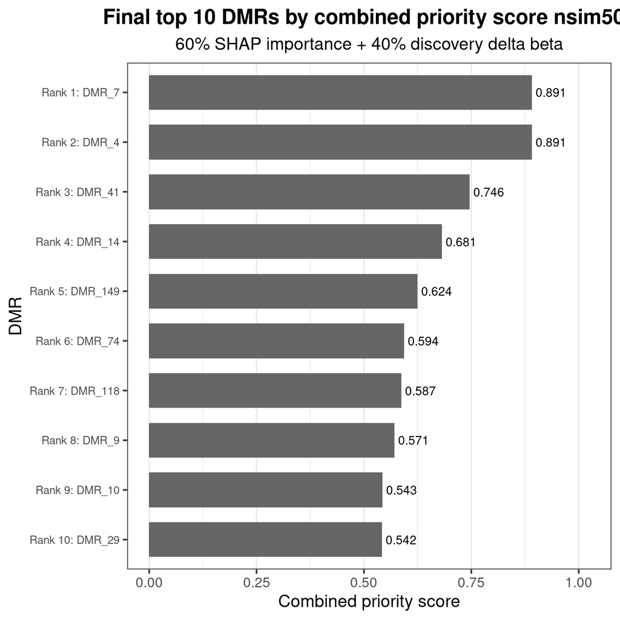

```r
print(p_priority_bar)
```

```r
ggsave(filename = file.path(outdir,
      "final_top10_combined_priority_score_barplot_nsim500.png"),
  plot = p_priority_bar,
  width = 10,
  height = 7,
  dpi = 300)

ggsave(
  filename = file.path(outdir,
 "final_top10_combined_priority_score_barplot_nsim500.pdf"),
  plot = p_priority_bar,
  width = 10,
  height = 7)
```

The files can be used in reports, presentations, and manuscript figures.

## Weighted score components

This chunk calculates the actual 60% SHAP and 40% discovery-delta contributions and confirms that their sum reproduces the priority score.

```r
top10_dmrs[, weighted_SHAP :=0.60 * score_SHAP]

top10_dmrs[, weighted_discovery_delta :=0.40 * score_discovery_delta]

############################################################
## Confirm that the two contributions reproduce the score
############################################################
top10_dmrs[, score_check :=weighted_SHAP +weighted_discovery_delta]

cat(
  "\nMaximum difference between priority_score and score_check:\n"
)
```

```
##
## Maximum difference between priority_score and score_check:
```

```r
print(
  max(
    abs(
      top10_dmrs$priority_score -
        top10_dmrs$score_check
    ),
    na.rm = TRUE
  )
)
```

```
## [1] 0
```

The maximum difference should be zero or extremely close to zero because of floating-point precision.

This chunk converts the two weighted score components to long format and assigns presentation labels.

```r
component_plot_df <- melt(
  top10_dmrs,
  id.vars = c(
    "Feature",
    "priority_rank",
    "DMR_label",
    "priority_score"
  ),
  measure.vars = c(
    "weighted_SHAP",
    "weighted_discovery_delta"
  ),
  variable.name = "Score_component",
  value.name = "Weighted_contribution"
)

component_plot_df[
  ,
  Score_component := factor(
    Score_component,
    levels = c(
      "weighted_SHAP",
      "weighted_discovery_delta"
    ),
    labels = c(
      "SHAP contribution (60%)",
      "Discovery delta contribution (40%)"))]
```

The long-format table is used to draw a stacked contribution plot.

This chunk creates the stacked barplot showing how much each scoring component contributes to the final score.

```r
p_component_bar <- ggplot(
  component_plot_df,
  aes(
    x = Weighted_contribution,
    y = DMR_label,
    fill = Score_component
  )
) +
  geom_col(width = 0.7) +
  geom_text(
    data = top10_dmrs,
    aes(
      x = priority_score,
      y = DMR_label,
      label = sprintf("%.3f", priority_score)
    ),
    inherit.aes = FALSE,
    hjust = -0.12,
    size = 3.4
  ) +
  scale_fill_manual(
    values = c(
      "SHAP contribution (60%)" = "#4C78A8",
      "Discovery delta contribution (40%)" = "#F58518"
    )
  ) +
  expand_limits(
    x = max(top10_dmrs$priority_score, na.rm = TRUE) * 1.15
  ) +
  labs(
    title = "Contribution to the final priority score nsim500",
    subtitle = "Weighted SHAP and discovery delta-beta components",
    x = "Weighted contribution",
    y = "DMR",
    fill = "Score component"
  ) +
  theme_bw(base_size = 14) +
  theme(
    plot.title = element_text(hjust = 0.5, face = "bold"),
    plot.subtitle = element_text(hjust = 0.5),
    axis.text.y = element_text(size = 9),
    panel.grid.major.y = element_blank(),
    legend.position = "top"
  )
```

The blue and orange segments sum to the total priority score displayed at the end of each bar.

This chunk displays and saves the weighted score-component plot in PNG and PDF formats.

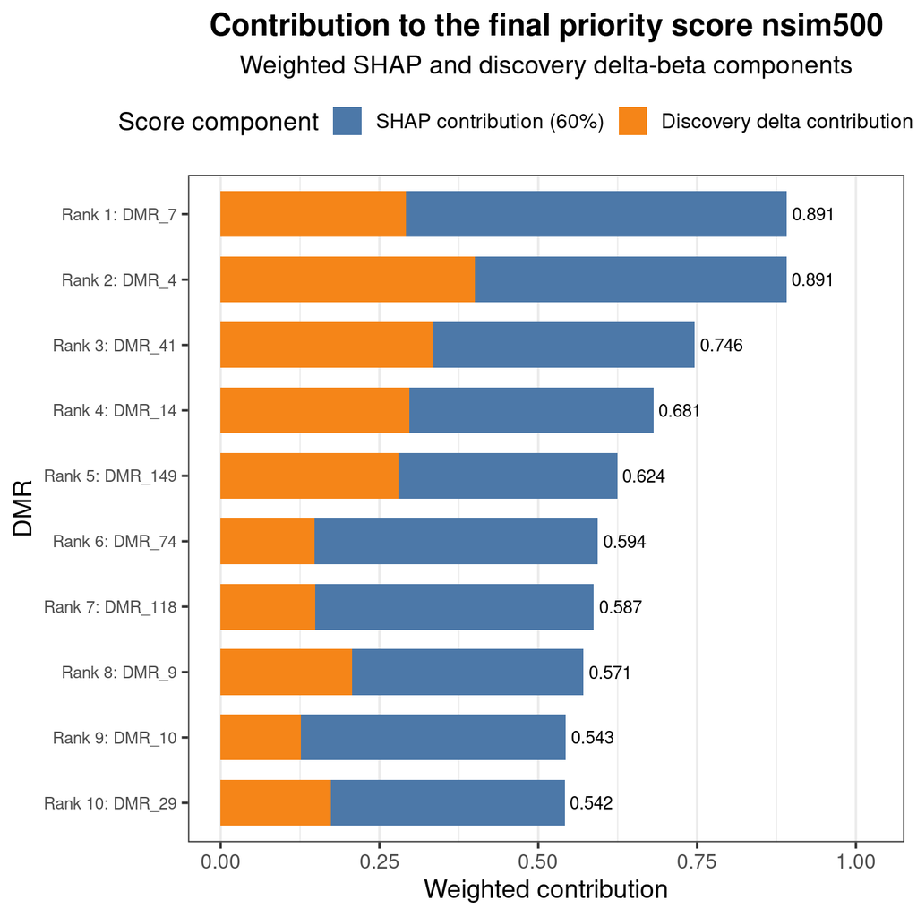

```r
print(p_component_bar)
```

```r
ggsave(
  filename = file.path(outdir,"final_top10_priority_score_components_nsim500.png"),
  plot = p_component_bar,
  width = 10,
  height = 7,
  dpi = 300)

ggsave(
  filename = file.path(outdir,"final_top10_priority_score_components_nsim500.pdf"),
  plot = p_component_bar,
  width = 10,
  height = 7)
```

The plot makes it possible to distinguish DMRs driven mainly by SHAP importance from those supported strongly by discovery effect size.

## SHAP summary beeswarm

This chunk identifies the selected top 10 features, constructs the rank-label mapping, and defines sample identifiers.

```r
selected_features_shap <- as.character( top10_dmrs$Feature)
selected_features_shap <- selected_features_shap[
  selected_features_shap %in% colnames(shap_svm)]

############################################################
## Create the feature-to-label mapping
############################################################

selected_label_map_shap <- top10_dmrs[Feature %in% selected_features_shap,
  .(Feature,
    priority_rank,
    DMR_label)]

selected_label_map_shap[
  ,
  DMR_label := as.character(DMR_label)]
############################################################
## Create sample identifiers
############################################################

sample_ids_shap <- rownames(x_explain)

if (is.null(sample_ids_shap)) {
  sample_ids_shap <- paste0(
    "Sample_",
    seq_len(nrow(x_explain))
  )
}
```

Only features present in the SHAP matrix are retained for the beeswarm plot.

This chunk converts the selected SHAP values from wide to long format.

```r
shap_dt <- as.data.table(
  shap_svm[
    ,
    selected_features_shap,
    drop = FALSE
  ]
)

shap_dt[, Sample := sample_ids_shap]

shap_long <- melt(
  shap_dt,
  id.vars = "Sample",
  measure.vars = selected_features_shap,
  variable.name = "Feature",
  value.name = "SHAP_value"
)
```

Each row of the long table represents one sample–DMR SHAP contribution.

This chunk converts the corresponding TCGA DMR beta values to long format.

```r
beta_dt <- as.data.table(
  as.data.frame(x_explain)[
    ,
    selected_features_shap,
    drop = FALSE
  ]
)

beta_dt[, Sample := sample_ids_shap]

beta_long <- melt(
  beta_dt,
  id.vars = "Sample",
  measure.vars = selected_features_shap,
  variable.name = "Feature",
  value.name = "DMR_beta"
)
```

These beta values provide the colour scale used in the SHAP summary plot.

This chunk joins the sample-level SHAP contributions with their corresponding DMR beta values.

```r
shap_plot_df <- merge(
  shap_long,
  beta_long,
  by = c(
    "Sample",
    "Feature"
  ),
  all.x = TRUE
)
```

The merged table links model contribution and methylation level for every selected sample–DMR pair.

This chunk adds the combined-priority rank and display label to the SHAP plotting table.

```r
shap_plot_df <- merge(
  shap_plot_df,
  selected_label_map_shap[
    ,
    .(
      Feature,
      priority_rank,
      DMR_label
    )
  ],
  by = "Feature",
  all.x = TRUE
)
```

The rank label ensures that the beeswarm order follows the final corrected priority ranking.

This chunk fixes the plotting order so that Rank 1 appears at the top.

```r
label_order_shap <- selected_label_map_shap[
  order(priority_rank),
  DMR_label
]

shap_plot_df[
  ,
  DMR_label := factor(
    DMR_label,
    levels = rev(label_order_shap)
  )
]
```

The factor order is shared across all points belonging to the same DMR.

This chunk constructs the SHAP summary beeswarm. Horizontal position represents contribution to predicted Tumor probability, and colour represents the DMR beta value.

```r
p_shap_beeswarm <- ggplot(
  shap_plot_df,
  aes(
    x = SHAP_value,
    y = DMR_label,
    color = DMR_beta
  )
) +
  ggbeeswarm::geom_quasirandom(
    groupOnX = FALSE,
    alpha = 0.75,
    size = 1.2,
    width = 0.25
  ) +
  scale_color_gradient(
    low = "#2C7BB6",
    high = "#D7191C"
  ) +
  geom_vline(
    xintercept = 0,
    linetype = "dashed",
    linewidth = 0.5
  ) +
  labs(
    title = "SHAP summary plot for the final top 10 DMRs nsim500",
    subtitle = "Top 10 selected using SHAP importance and discovery delta beta",
    x = "SHAP value for predicted Tumor probability",
    y = "DMR",
    color = "DMR beta"
  ) +
  theme_bw(base_size = 14) +
  theme(
    plot.title = element_text(
      hjust = 0.5,
      face = "bold"
    ),
    plot.subtitle = element_text(
      hjust = 0.5
    ),
    axis.text.y = element_text(size = 9)
  )
```

Red points at positive SHAP values indicate high methylation values that push predictions toward Tumor.

This chunk displays and saves the SHAP summary beeswarm in PNG and PDF formats.

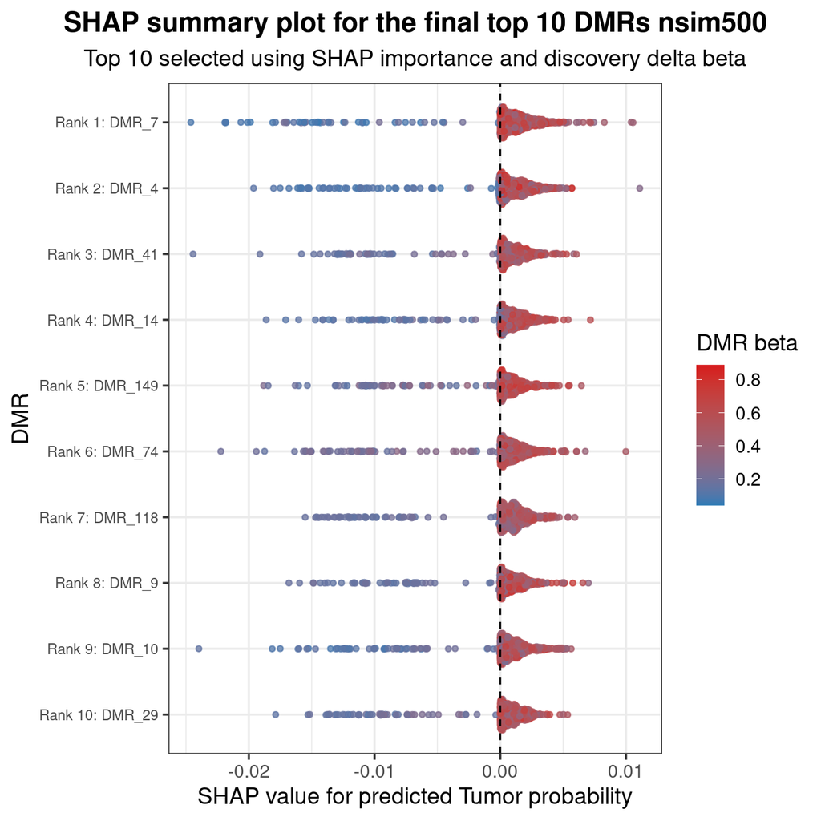

```r
print(p_shap_beeswarm)
```

```r
ggsave(filename = file.path(outdir,"final_top10_SHAP_summary_beeswarm_nsim500.png"),
  plot = p_shap_beeswarm,
  width = 10,
  height = 7,
  dpi = 300)

ggsave(filename = file.path(outdir,"final_top10_SHAP_summary_beeswarm_nsim500.pdf"),
  plot = p_shap_beeswarm,
  width = 10,
  height = 7)
```

The plot provides sample-level direction and magnitude information beyond the mean absolute SHAP ranking.

## TCGA Tumor–Normal beta distributions

This chunk identifies the top 10 features present in the TCGA dataframe and creates their rank-label mapping.

```r
selected_features_beta <- as.character(
  top10_dmrs$Feature)

selected_features_beta <- selected_features_beta[
  selected_features_beta %in% colnames(test_df_full)]

missing_beta_features <- setdiff(
  as.character(top10_dmrs$Feature),
  selected_features_beta)

############################################################
## Create feature-to-label mapping
############################################################

selected_label_map_beta <- top10_dmrs[
  Feature %in% selected_features_beta,
  .(
    Feature,
    priority_rank,
    DMR_label
  )
]

selected_label_map_beta[
  ,
  DMR_label := as.character(DMR_label)
]
```

Any missing selected feature would be recorded before plotting.

This chunk prepares sample identifiers and converts the selected TCGA beta values to long format.

```r
test_df_plot <- as.data.frame(test_df_full)

sample_ids_beta <- rownames(test_df_plot)

if (is.null(sample_ids_beta)) {
  sample_ids_beta <- paste0(
    "Sample_",
    seq_len(nrow(test_df_plot))
  )
}

beta_selected_dt <- as.data.table(
  test_df_plot[
    ,
    c(
      "group",
      selected_features_beta
    ),
    drop = FALSE
  ]
)

beta_selected_dt[, Sample := sample_ids_beta]

## Convert TCGA beta data to long format
beta_selected_long <- melt(
  beta_selected_dt,
  id.vars = c(
    "Sample",
    "group"
  ),
  measure.vars = selected_features_beta,
  variable.name = "Feature",
  value.name = "DMR_beta"
)
```

The long table contains one DMR beta value for each sample, feature, and diagnostic group.

This chunk adds the corrected priority labels, fixes the Normal–Tumor group order, and arranges plot facets from Rank 1 to Rank 10.

```r
beta_selected_long <- merge(
  beta_selected_long,
 selected_label_map_beta[,.(
      Feature,
      priority_rank,
      DMR_label)],
  by = "Feature",
  all.x = TRUE)

## Set the group order
beta_selected_long[,group := factor(as.character(group),levels = c("Normal","Tumor"))]
## Arrange facets from priority rank 1 to rank 10
label_order_beta <- selected_label_map_beta[
  order(priority_rank),
  DMR_label]

beta_selected_long[,DMR_label := factor(DMR_label,levels = label_order_beta)]
```

The prepared dataframe is ready for direct visual comparison of methylation distributions.

This chunk constructs faceted boxplots with beeswarm points for Normal and Tumor samples in the TCGA full cohort.

```r
p_beta_box_beeswarm <- ggplot(
  beta_selected_long,
  aes(
    x = group,
    y = DMR_beta,
    color = group,
    fill = group
  )
) +
  geom_boxplot(
    outlier.shape = NA,
    alpha = 0.25,
    width = 0.55
  ) +
  ggbeeswarm::geom_quasirandom(
    width = 0.18,
    alpha = 0.55,
    size = 1.1
  ) +
  facet_wrap(~ DMR_label, ncol = 2, scales = "free_y") +
  scale_color_manual(
    values = c("Normal" = "#2C7BB6", "Tumor" = "#D7191C")
  ) +
  scale_fill_manual(
    values = c("Normal" = "#2C7BB6", "Tumor" = "#D7191C")
  ) +
  labs(
    title = "TCGA confirmation of the final top 10 DMRs nsim500",
    subtitle = "Final candidates selected using SHAP and discovery delta beta",
    x = NULL,
    y = "DMR mean beta value",
    color = "Group",
    fill = "Group"
  ) +
  theme_bw(base_size = 14) +
  theme(
    plot.title = element_text(hjust = 0.5, face = "bold"),
    plot.subtitle = element_text(hjust = 0.5),
    strip.text = element_text(size = 9),
    axis.text.x = element_text(size = 10),
    legend.position = "top"
  )
```

Clear upward shifts in the Tumor group support the external reproducibility of the selected hypermethylated DMRs.

This chunk displays and saves the TCGA beta distribution figure in PNG and PDF formats.

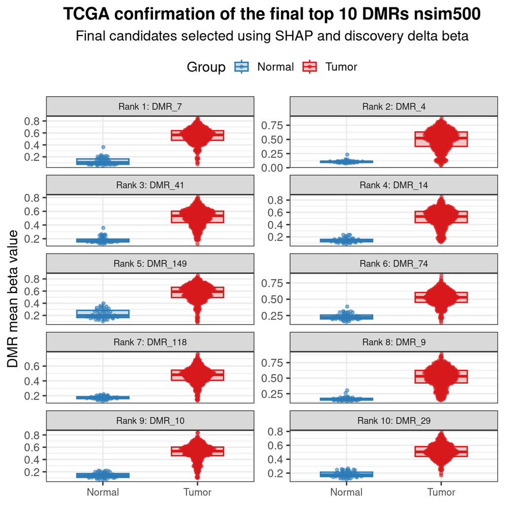

```r
print(p_beta_box_beeswarm)
```

```r
## Save the TCGA beta boxplot and beeswarm
ggsave(filename = file.path(outdir,"final_top10_TCGA_beta_boxplot_beeswarm_nsim500.png"),
  plot = p_beta_box_beeswarm,
  width = 11,
  height = 12,
  dpi = 300
)

ggsave(filename = file.path(outdir,"final_top10_TCGA_beta_boxplot_beeswarm_nsim500.pdf"),
  plot = p_beta_box_beeswarm,
  width = 11,
  height = 12)
```

The figure provides an external visual check of the Tumor–Normal separation for each final candidate.

This chunk saves the corrected ranked tables, plotting dataframes, and figure objects in one RData file.

```r
save(priority_table_scored,
  top10_dmrs,
  component_plot_df,
  shap_plot_df,
  beta_selected_long,
  p_priority_bar,
  p_component_bar,
  p_shap_beeswarm,
  p_beta_box_beeswarm,
  file = file.path(outdir,"final_top10_DMR_visualisation_results_full_nsim500.Rdata"))
```

The saved object bundle allows the figures and result tables to be reopened without repeating the SHAP calculation.

# Session information